# easylabel

## Installation

Install from Github

```r
devtools::install_github("myles-lewis/easylabel", auth_token="...")
library(easylabel)
```

## Simple instructions:

- Hover over and click on/off genes which you want to label.
- When you have selected all your chosen genes, then drag gene names to move label positions.
- Click the save button to export a PDF in base graphics.

## To export an SVG from plotly:

- You can move the legend as well.
- Switch to SVG when finalised (only do this at last moment as otherwise editing is very slow).
- Press camera button in modebar to save image as SVG.

## Examples:

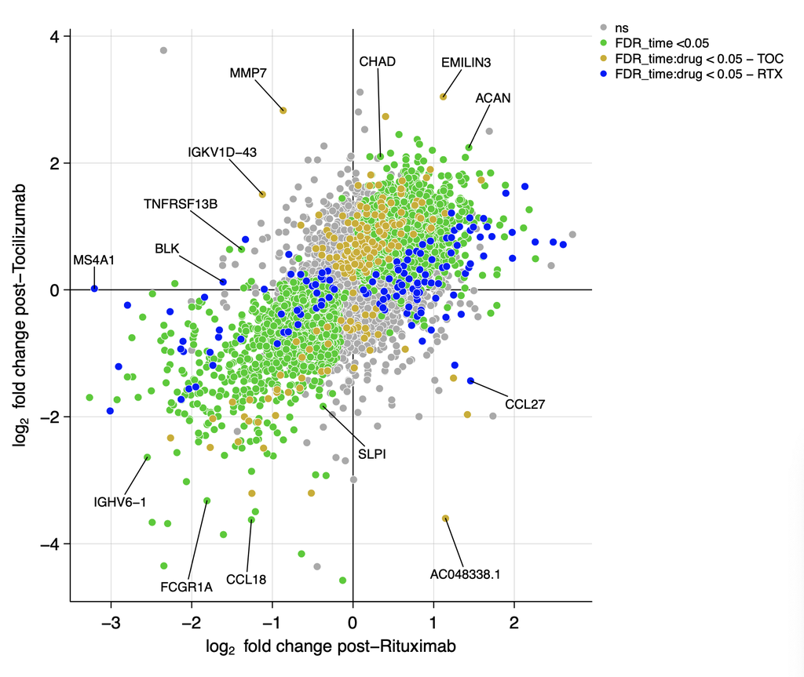

```r
easylabel(ymatrix, x = 'x', y = 'y', col = 'col',
          scheme = c('darkgrey', 'green3', 'gold3', 'blue'),
          xlab = expression("log"[2] ~ " fold change post-Rituximab"),
          ylab = expression("log"[2] ~ " fold change post-Tocilizumab"),
          showgrid = TRUE)
```

Use the `volcanoplot()` function to quickly plot a volcano plot from DESeq2 or EdgeR objects. The `useQ` argument will switch to using q values for FDR.

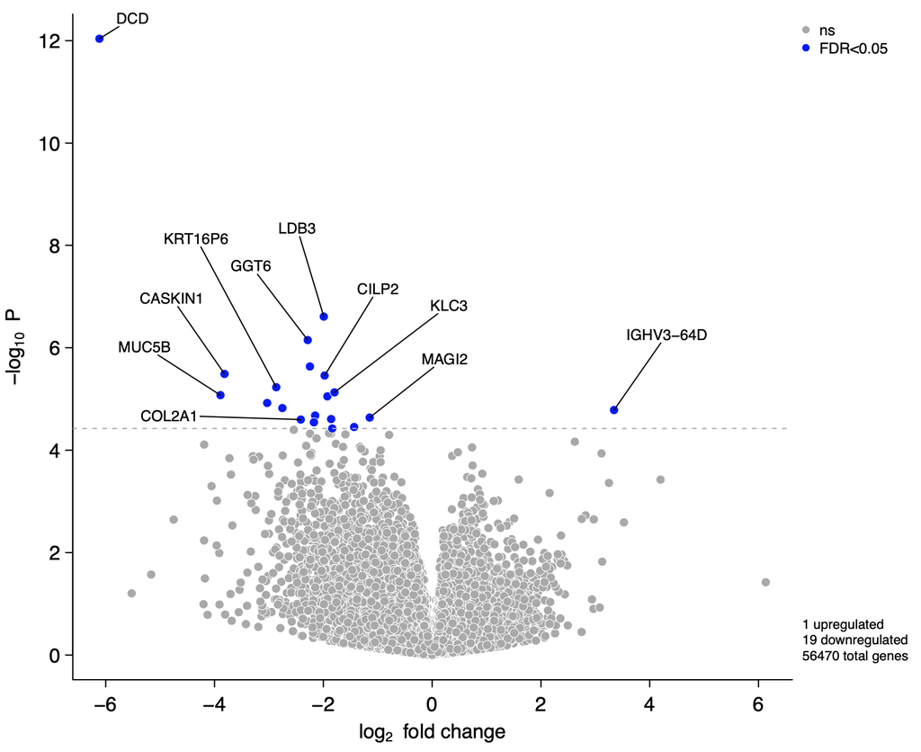

```r
volcanoplot(volc1, useQ = TRUE)
```

The `fullGeneNames` argument will use Bioconductor package `AnnotationDbi` and the `org.Hs.eg.db` human gene database to expand gene symbols in the Table tab. Both will need to be installed from Bioconductor.

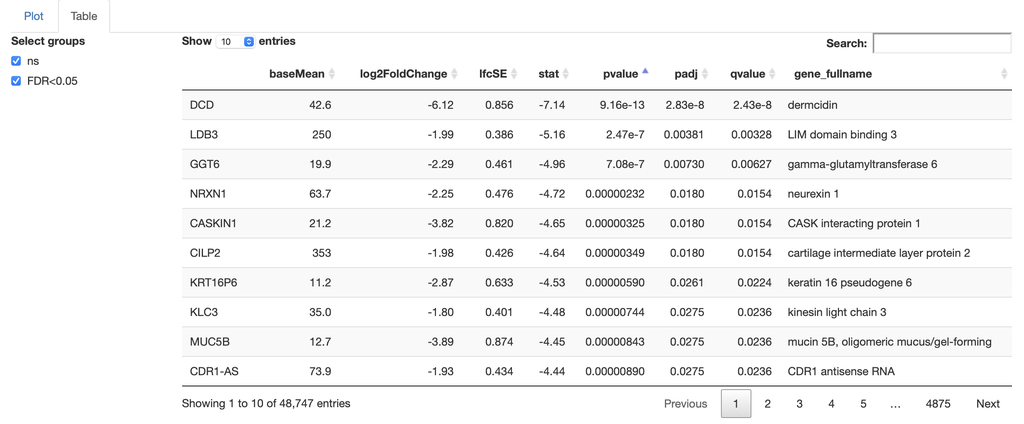

```r
BiocManager::install("AnnotationDbi")
BiocManager::install("org.Hs.eg.db")
volcanoplot(volc1, useQ = TRUE, fullGeneNames = TRUE)
```

You can add left and right sided titles using `Ltitle` and `Rtitle` to explain the direction of effect for up/downregulation. The use of `expression` in the example below shows how to add left/right arrow symbols to the titles. `LRtitle_side = 1` puts these titles on the bottom while `= 3` puts them on the top. `cex.lab` controls font size for these titles as well as axis titles. `cex.axis` controls font size for axis numbering.

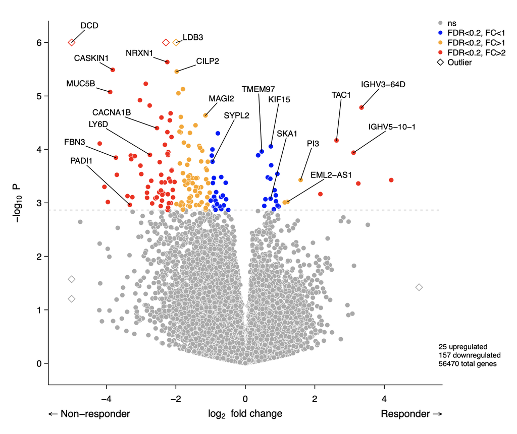

```r
volcanoplot(volc1,
            useQ = TRUE, fullGeneNames = TRUE,
            Ltitle=expression(symbol("\254") ~ "Non-responder"),
            Rtitle=expression("Responder" ~ symbol("\256")),
            LRtitle_side=1,
            cex.lab=0.9, cex.axis=0.8,
            fccut = c(1, 2), fdrcutoff = 0.2,
            ylim = c(0, 6), xlim=c(-5,5),
            scheme=c('darkgrey', 'blue', 'orange', 'red'))
```

In the next 2 plots, the colours range from blue for downregulated genes, through to red for upregulated genes. Vertical lines can be added using `vline`.

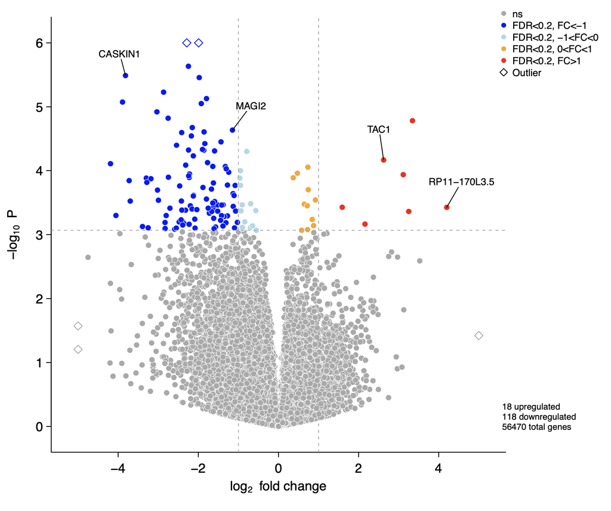

```r
volcanoplot(volc1, fccut = 1, fdrcutoff = 0.2, ylim = c(0, 6), xlim=c(-5,5),
            scheme=c('darkgrey', 'blue', 'lightblue', 'orange', 'red'), vline=c(-1,1))
```

The next example has 6 colours and also shows how to remove the white outlines around points using `outline_col = NA` and use transparency instead via `alpha`.

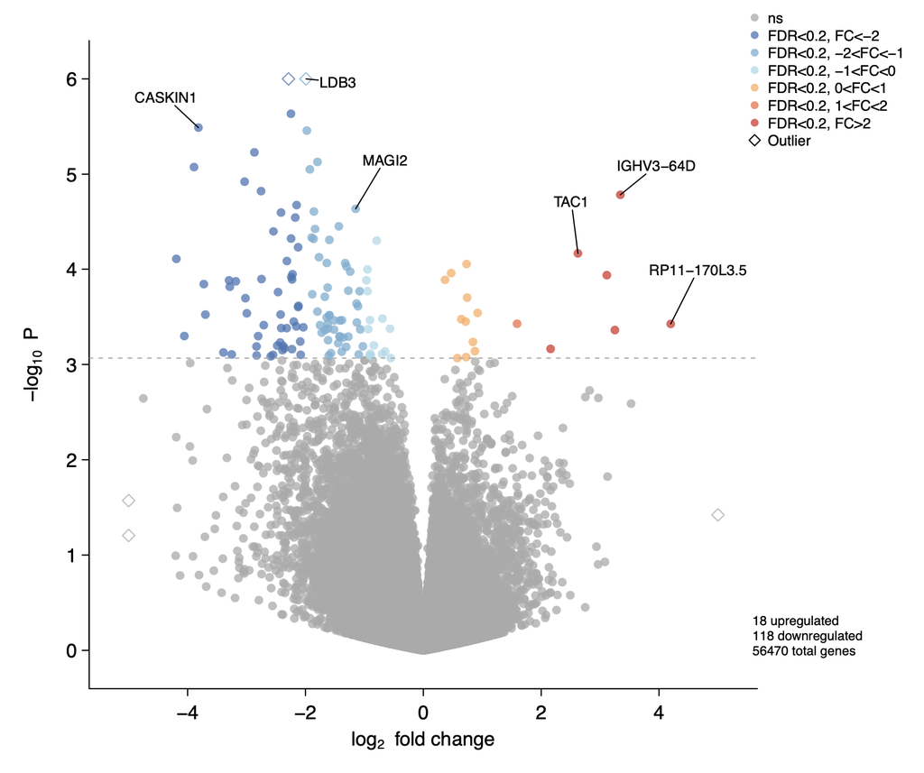

```r
library(RColorBrewer)
volcanoplot(volc1, fccut = c(1, 2), fdrcutoff = 0.2, ylim = c(0, 6), xlim=c(-5,5),
            scheme=c('darkgrey', rev(brewer.pal(9, 'RdYlBu')[-(4:6)])), alpha=0.75, outline_col=NA)
```

The size of markers can be changed using `cex` (default 1). A box around the plot can be added using `bty='o'` (see `par()`). Axes can be customised by first suppressing the initial axis using `xaxt='n'` or `yaxt='n'` and then adding an `axis()` call using `panel.last`. A top title can also be added using `mtext()` via `panel.last`.

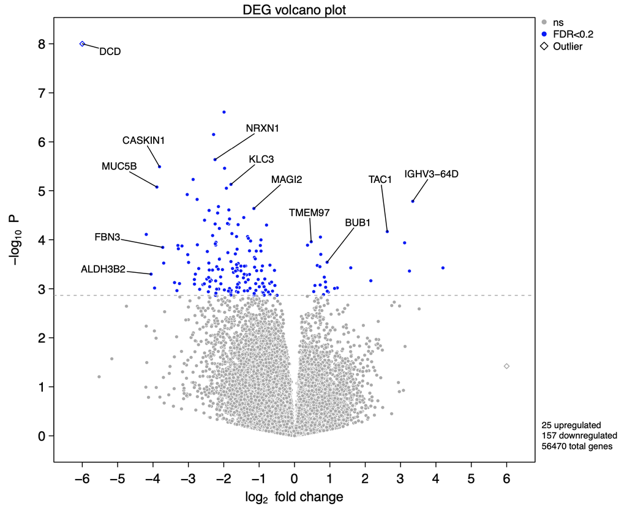

```r
volcanoplot(volc1, useQ = TRUE, fdrcutoff = 0.2, ylim=c(0,8), xlim=c(-6,6),
            cex = 0.6,
            xaxt = 'n', yaxt = 'n', bty = 'o', panel.last = {
            axis(side = 1, at = -6:6)
            axis(side = 2, at = 0:8)
            mtext("DEG volcano plot", side = 3)
            })
```